# Part 2: Data Analysis

Jahiya Clark

12/10/2021

# Part 2: Data Analysis

## Data Exploration

```r
require(here)
delomys <- read.csv(here("data", "delomys.csv"))
summary(delomys)
```

```
##        X            genus             binomial           body_mass
##  Min.   :27526   Length:1585        Length:1585        Min.   :  5.00
##  1st Qu.:27950   Class :character   Class :character   1st Qu.: 35.00
##  Median :28348   Mode  :character   Mode  :character   Median : 43.00
##  Mean   :28371                                         Mean   : 44.06
##  3rd Qu.:28790                                         3rd Qu.: 54.00
##  Max.   :35552                                         Max.   :105.00
##   body_length        age                sex              longitude
##  Min.   : 49.0   Length:1585        Length:1585        Min.   :-49681671
##  1st Qu.:106.0   Class :character   Class :character   1st Qu.:      -50
##  Median :116.0   Mode  :character   Mode  :character   Median :      -50
##  Mean   :114.7                                         Mean   :   -62739
##  3rd Qu.:124.0                                         3rd Qu.:      -47
##  Max.   :265.0                                         Max.   :      -41
##     latitude            status
##  Min.   :-22383667   Length:1585
##  1st Qu.:      -29   Class :character
##  Median :      -29   Mode  :character
##  Mean   :   -28272
##  3rd Qu.:      -24
##  Max.   :      -20
```

```r
shapiro.test(delomys$body_mass)
```

```
##
##  Shapiro-Wilk normality test
##
## data:  delomys$body_mass
## W = 0.99506, p-value = 4.33e-05
```

```r
shapiro.test(delomys$body_length)
```

```
##
##  Shapiro-Wilk normality test
##
## data:  delomys$body_length
## W = 0.87609, p-value < 2.2e-16
```

```r
require(palmerpenguins)
```

[figure not shown]

```r
plot(bill_length_mm ~ body_mass_g, data = penguins)
```

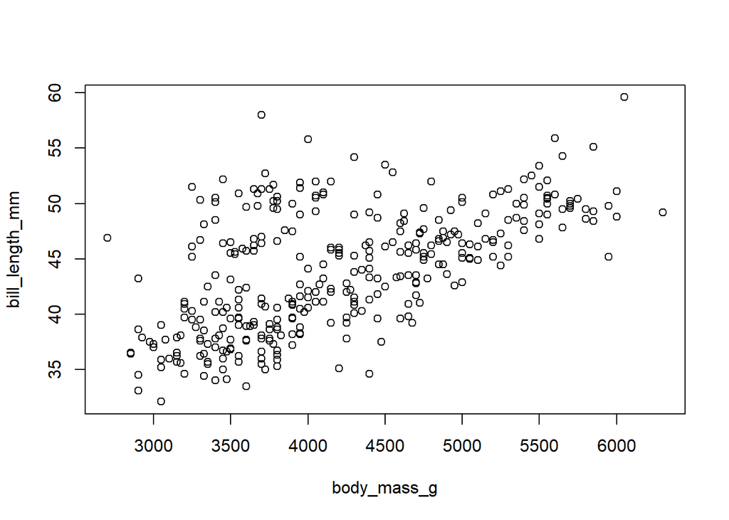

```r
require(palmerpenguins)
plot(bill_length_mm ~ body_mass_g, data = penguins)
```

## Graphical Exploration

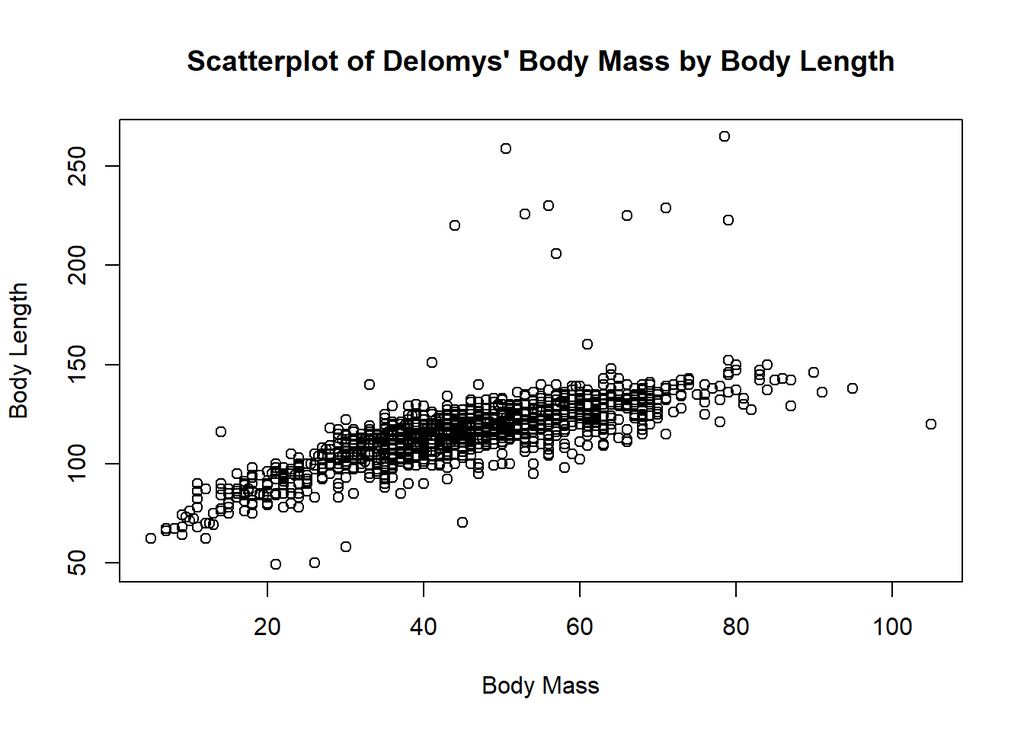

```r
plot(delomys$body_length ~ delomys$body_mass, main = "Scatterplot of Delomys' Body Mass by Body Length",
     xlab = "Body Mass",
     ylab = "Body Length")
```

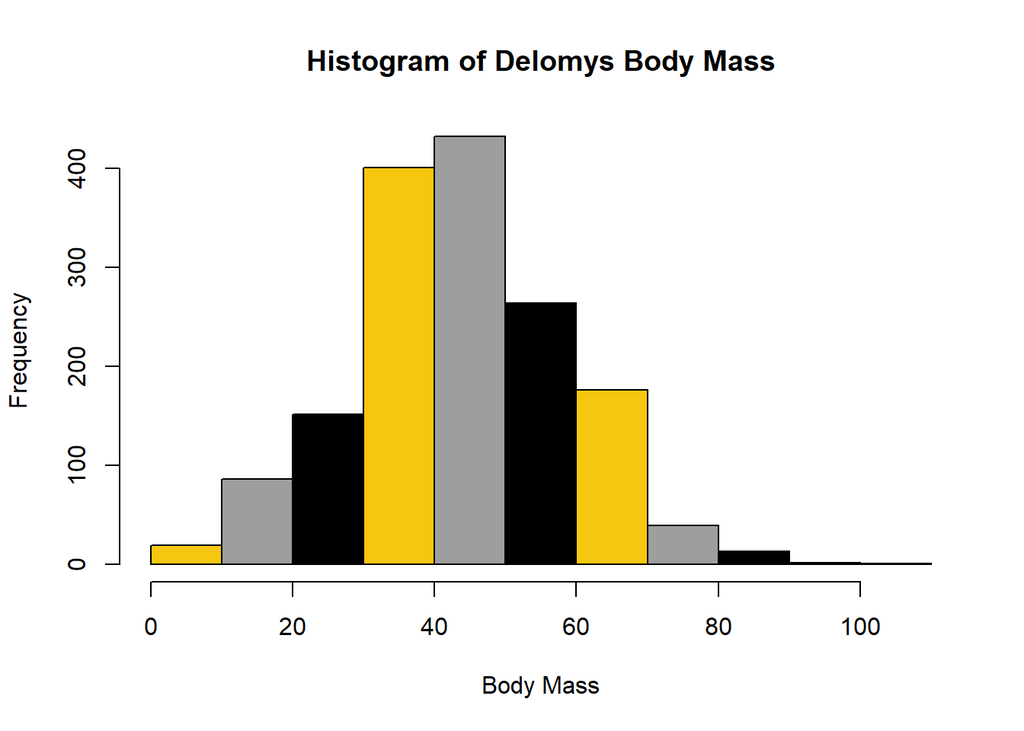

```r
hist(delomys$body_mass, main = "Histogram of Delomys Body Mass", xlab = "Body Mass", col = 7:9)
```

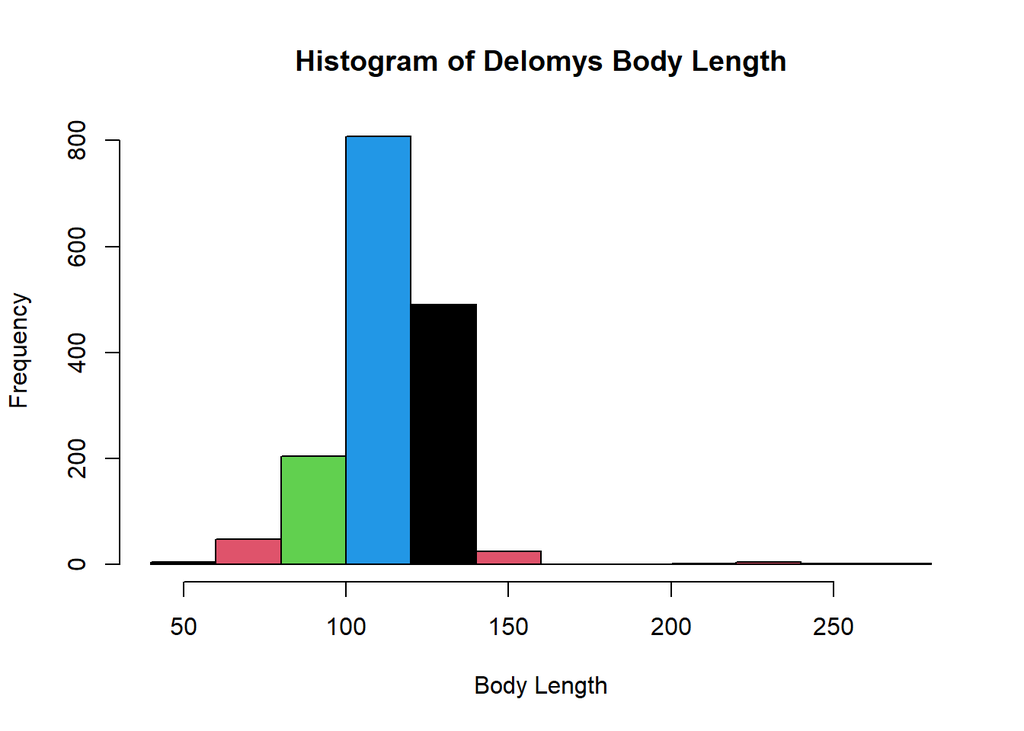

```r
hist(delomys$body_length, main = "Histogram of Delomys Body Length", xlab = "Body Length", col = 1:4)
```

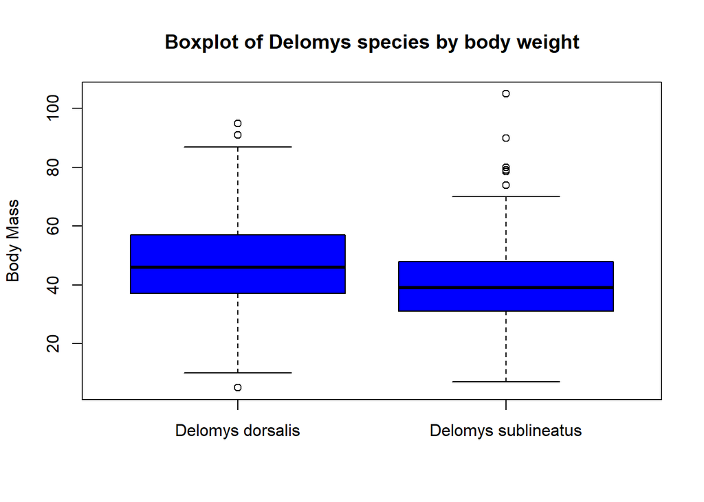

```r
boxplot(body_mass ~ binomial, data = delomys, main = "Boxplot of Delomys species by body weight", xlab = "" , ylab = "Body Mass", col = "blue")
```

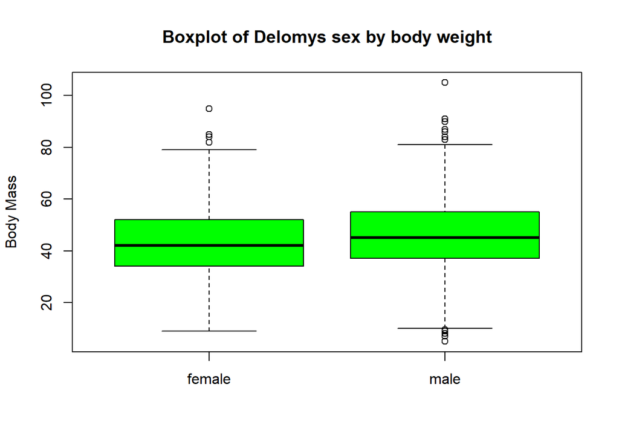

```r
boxplot(body_mass ~ sex, data = delomys, main = "Boxplot of Delomys sex by body weight", xlab = "" , ylab = "Body Mass", col = "green")
```

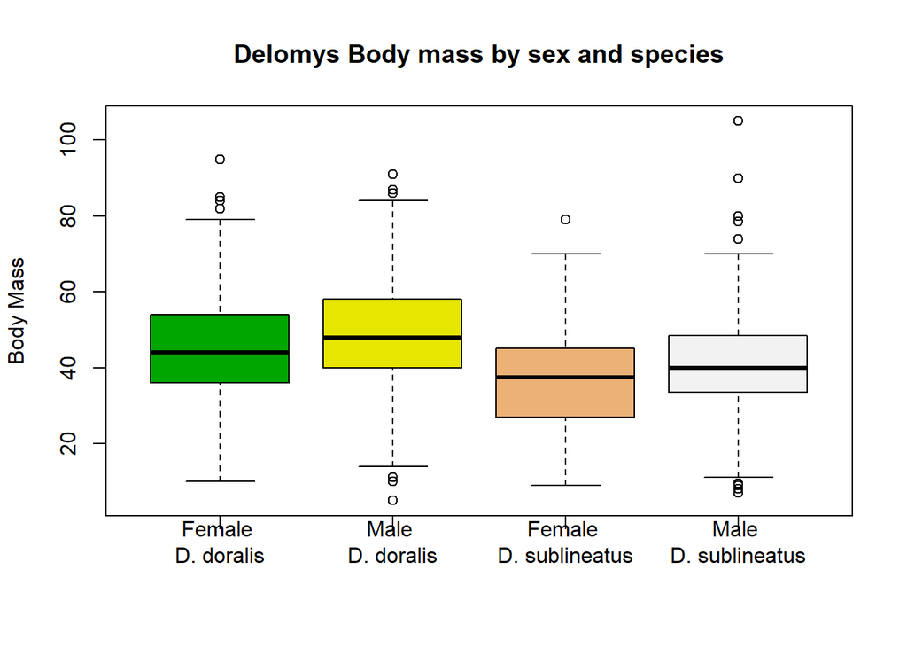

```r
con_box <-
  lm(
    formula = delomys$body_mass ~ delomys$sex *
  delomys$binomial)


boxplot(
  formula(con_box),
  main = "Delomys Body mass by sex and species",
  ylab = "Body Mass",
  xlab = "",
  names = c("Female \nD. doralis", "Male \nD. doralis",
            "Female \nD. sublineatus", "Male \nD. sublineatus"),
  col = terrain.colors(4)
)
```

## Questions 1-4

### Question 1

From the scatterplots of body mass and body length, there seem to be a positive linear relationship between the variables. As body mass increases, so does body length of Delomys species.

### Question 2

The histograms depicting body mass and body length of Delomys are both right skewed shaped. The histogram of body length has a longer tail to the right than the histogram of body mass. They do not come off as completely normal shaped but body mass more so than body length.

### Question 3

The Shapiro Wilk normality test for Body mass produced a p-value of 4.33e-05, which allows us to reject the null hypothesis that the data is normally distributed. Which I think differs from the histogram of body mass that shows a bell shape trend. Additionally, we can reject the null hypothesis of the Shapiro wilk test for body length that the data is normally distributed because the p-value is 2.2e-16. This interpretation can be backed with the histogram of body length, that shows a very right skewed trend.

### Question 4

The conditional boxplot depicting Delomys body mass by sex and species doesn’t provide any strong graphical evidence of differences. There does seem to be a difference between the sexes of both species; where males weigh more than females but it seems like a small difference. Additionally, there seems to be a small difference between *D. doralis* being heavier than *D. sublineatus*.

## Model Building

```r
fit1 = lm(delomys$body_length ~ delomys$body_mass)

fit2 = lm(delomys$body_mass~ delomys$sex)

fit3 = lm(delomys$body_mass ~ delomys$binomial)

fit4 = lm(delomys$body_mass ~ delomys$sex + delomys$binomial)

fit5 = lm(delomys$body_mass ~ delomys$sex * delomys$binomial)
```

## Model Diagnostics

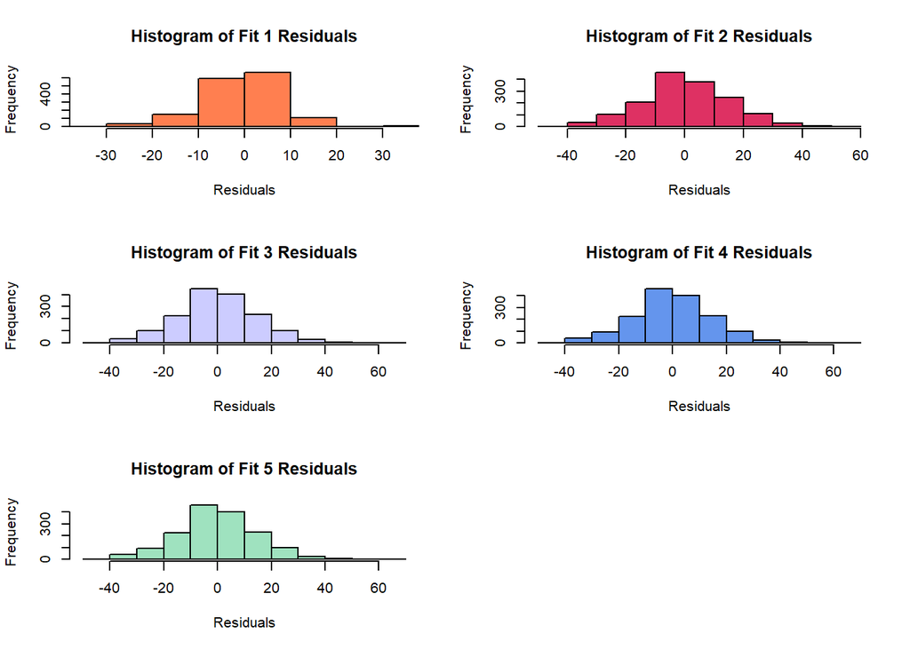

```r
par(mfrow = c(3, 2))
hist(residuals(fit1), main = "Histogram of Fit 1 Residuals", xlab = "Residuals", col = "#FF7F50", , xlim = c(-35,35), breaks = 25)
hist(residuals(fit2),  main = "Histogram of Fit 2 Residuals", xlab = "Residuals", col = "#DE3163")
hist(residuals(fit3),  main = "Histogram of Fit 3 Residuals", xlab = "Residuals", col = "#CCCCFF")
hist(residuals(fit4),  main = "Histogram of Fit 4 Residuals", xlab = "Residuals", col = "#6495ED")
hist(residuals(fit5),  main = "Histogram of Fit 5 Residuals", xlab = "Residuals", col = "#9FE2BF")
```

```r
shapiro.test(residuals(fit1))
```

```
##
##  Shapiro-Wilk normality test
##
## data:  residuals(fit1)
## W = 0.73462, p-value < 2.2e-16
```

```r
shapiro.test(residuals(fit2))
```

```
##
##  Shapiro-Wilk normality test
##
## data:  residuals(fit2)
## W = 0.99563, p-value = 0.0001541
```

```r
shapiro.test(residuals(fit3))
```

```
##
##  Shapiro-Wilk normality test
##
## data:  residuals(fit3)
## W = 0.99535, p-value = 8.103e-05
```

```r
shapiro.test(residuals(fit4))
```

```
##
##  Shapiro-Wilk normality test
##
## data:  residuals(fit4)
## W = 0.99525, p-value = 6.805e-05
```

```r
shapiro.test(residuals(fit5))
```

```
##
##  Shapiro-Wilk normality test
##
## data:  residuals(fit5)
## W = 0.99526, p-value = 6.816e-05
```

## Questions 5-6

### Question 6

No, the models do not have equally severe violations of normality assumption. For instance, fit4 and fit5 have the possibility of violating the assumption of independence and implicit factor because we are testing two explanatory variables that may have implicit factors.

## Model Interpretation

```r
knitr::kable(coef(summary(fit1)))
```

|  | Estimate | Std. Error | t value | Pr(>\|t\|) |
| --- | --- | --- | --- | --- |
| (Intercept) | 76.1246565 | 0.9158120 | 83.12258 | 0 |
| delomys$body_mass | 0.8754988 | 0.0196905 | 44.46298 | 0 |

```r
knitr::kable(coef(summary(fit2)))
```

|  | Estimate | Std. Error | t value | Pr(>\|t\|) |
| --- | --- | --- | --- | --- |
| (Intercept) | 42.711465 | 0.5288929 | 80.756355 | 0.0000000 |
| delomys$sexmale | 2.784133 | 0.7456117 | 3.734024 | 0.0001951 |

```r
knitr::kable(coef(summary(fit3)))
```

|  | Estimate | Std. Error | t value | Pr(>\|t\|) |
| --- | --- | --- | --- | --- |
| (Intercept) | 46.752427 | 0.4499933 | 103.89582 | 0 |
| delomys$binomialDelomys sublineatus | -7.683058 | 0.7604562 | -10.10322 | 0 |

```r
knitr::kable(coef(summary(fit4)))
```

[output not shown]

```r
knitr::kable(coef(summary(fit5)))
```

[output not shown]

## Questions 7-9 Body Length

```r
summary(fit1)
```

```
##
## Call:
## lm(formula = delomys$body_length ~ delomys$body_mass)
##
## Residuals:
##     Min      1Q  Median      3Q     Max
## -48.888  -5.398   0.104   4.859 138.663
##
## Coefficients:
##                   Estimate Std. Error t value Pr(>|t|)
## (Intercept)       76.12466    0.91581   83.12   <2e-16 ***
## delomys$body_mass  0.87550    0.01969   44.46   <2e-16 ***
## ---
## Signif. codes:  0 '***' 0.001 '**' 0.01 '*' 0.05 '.' 0.1 ' ' 1
##
## Residual standard error: 11.67 on 1583 degrees of freedom
## Multiple R-squared:  0.5553, Adjusted R-squared:  0.5551
## F-statistic:  1977 on 1 and 1583 DF,  p-value: < 2.2e-16
```

```r
summary(fit2)
```

```
##
## Call:
## lm(formula = delomys$body_mass ~ delomys$sex)
##
## Residuals:
##     Min      1Q  Median      3Q     Max
## -40.496  -8.711  -0.496   9.504  59.504
##
## Coefficients:
##                 Estimate Std. Error t value Pr(>|t|)
## (Intercept)      42.7115     0.5289  80.756  < 2e-16 ***
## delomys$sexmale   2.7841     0.7456   3.734 0.000195 ***
## ---
## Signif. codes:  0 '***' 0.001 '**' 0.01 '*' 0.05 '.' 0.1 ' ' 1
##
## Residual standard error: 14.82 on 1578 degrees of freedom
##   (5 observations deleted due to missingness)
## Multiple R-squared:  0.008758,   Adjusted R-squared:  0.00813
## F-statistic: 13.94 on 1 and 1578 DF,  p-value: 0.0001951
```

```r
summary(fit3)
```

```
##
## Call:
## lm(formula = delomys$body_mass ~ delomys$binomial)
##
## Residuals:
##     Min      1Q  Median      3Q     Max
## -41.752  -9.069  -0.069   9.248  65.931
##
## Coefficients:
##                                     Estimate Std. Error t value Pr(>|t|)
## (Intercept)                          46.7524     0.4500   103.9   <2e-16 ***
## delomys$binomialDelomys sublineatus  -7.6831     0.7605   -10.1   <2e-16 ***
## ---
## Signif. codes:  0 '***' 0.001 '**' 0.01 '*' 0.05 '.' 0.1 ' ' 1
##
## Residual standard error: 14.44 on 1583 degrees of freedom
## Multiple R-squared:  0.06058,    Adjusted R-squared:  0.05998
## F-statistic: 102.1 on 1 and 1583 DF,  p-value: < 2.2e-16
```

```r
summary(fit4)
```

```
##
## Call:
## lm(formula = delomys$body_mass ~ delomys$sex + delomys$binomial)
##
## Residuals:
##     Min      1Q  Median      3Q     Max
## -43.866  -8.866  -0.672   8.930  64.328
##
## Coefficients:
##                                     Estimate Std. Error t value Pr(>|t|)
## (Intercept)                          45.0704     0.5556  81.114  < 2e-16 ***
## delomys$sexmale                       3.7954     0.7260   5.228 1.94e-07 ***
## delomys$binomialDelomys sublineatus  -8.1935     0.7610 -10.767  < 2e-16 ***
## ---
## Signif. codes:  0 '***' 0.001 '**' 0.01 '*' 0.05 '.' 0.1 ' ' 1
##
## Residual standard error: 14.31 on 1577 degrees of freedom
##   (5 observations deleted due to missingness)
## Multiple R-squared:  0.07663,    Adjusted R-squared:  0.07546
## F-statistic: 65.44 on 2 and 1577 DF,  p-value: < 2.2e-16
```

```r
summary(fit5)
```

```
##
## Call:
## lm(formula = delomys$body_mass ~ delomys$sex * delomys$binomial)
##
## Residuals:
##     Min      1Q  Median      3Q     Max
## -43.884  -8.884  -0.647   8.945  64.353
##
## Coefficients:
##                                                     Estimate Std. Error t value
## (Intercept)                                         45.05546    0.60530  74.435
## delomys$sexmale                                      3.82809    0.89667   4.269
## delomys$binomialDelomys sublineatus                 -8.14174    1.12810  -7.217
## delomys$sexmale:delomys$binomialDelomys sublineatus -0.09502    1.52859  -0.062
##                                                     Pr(>|t|)
## (Intercept)                                          < 2e-16 ***
## delomys$sexmale                                     2.08e-05 ***
## delomys$binomialDelomys sublineatus                 8.22e-13 ***
## delomys$sexmale:delomys$binomialDelomys sublineatus     0.95
## ---
## Signif. codes:  0 '***' 0.001 '**' 0.01 '*' 0.05 '.' 0.1 ' ' 1
##
## Residual standard error: 14.31 on 1576 degrees of freedom
##   (5 observations deleted due to missingness)
## Multiple R-squared:  0.07664,    Adjusted R-squared:  0.07488
## F-statistic:  43.6 on 3 and 1576 DF,  p-value: < 2.2e-16
```

### Question 7

The p-value of the relationship body length and body mass is 2.2e-16, meaning we can reject the null hypothesis and that there is a relationship between the two variables. Yet, the R<sup>2</sup> value is 0.5553, which can mean 55% of the variance found in body length can be explained by the body mass.

### Question 8

The body length is expected to be 163.67

```r
"y= mx + b"
```

```
## [1] "y= mx + b"
```

```r
y = (0.87550)*(100) + (76.12466)
y
```

```
## [1] 163.6747
```

### Question 9

The expected body length is 76.12.

```r
"y= mx + b"
```

```
## [1] "y= mx + b"
```

```r
y = (0.87550)*(0) + (76.12466)
y
```

```
## [1] 76.12466
```

## Questions 10-13 Body Mass: Model Coefficients

### Question 10

The base case for sex is 42.7115

### Question 11

The base case for binomial is 46.7524.

### Question 12

Males are the heavier sex.

## Questions 14-16 Body Mass: ANOVA

```r
knitr::kable(anova(fit1))
```

|  | Df | Sum Sq | Mean Sq | F value | Pr(>F) |
| --- | --- | --- | --- | --- | --- |
| delomys$body_mass | 1 | 269388.9 | 269388.9086 | 1976.957 | 0 |
| Residuals | 1583 | 215706.6 | 136.2645 | NA | NA |

```r
knitr::kable(anova(fit2))
```

|  | Df | Sum Sq | Mean Sq | F value | Pr(>F) |
| --- | --- | --- | --- | --- | --- |
| delomys$sex | 1 | 3061.678 | 3061.6779 | 13.94294 | 0.0001951 |
| Residuals | 1578 | 346507.131 | 219.5863 | NA | NA |

```r
knitr::kable(anova(fit3))
```

|  | Df | Sum Sq | Mean Sq | F value | Pr(>F) |
| --- | --- | --- | --- | --- | --- |
| delomys$binomial | 1 | 21289.68 | 21289.6805 | 102.0751 | 0 |
| Residuals | 1583 | 330164.45 | 208.5688 | NA | NA |

```r
knitr::kable(anova(fit4))
```

[output not shown]

```r
knitr::kable(anova(fit5))
```

[output not shown]

### Question 14

Yes both sex and species are significant predictors of body mass. They have p-values of 0.0001951 (sex) and 0 (species).

### Question 15

According to the p-values they are all significant interactions except the factorial interaction between both sex and species (p-value is 0.9504).

### Question 16

The significance of the main effects stay significant in the single predictor models and the additive model. But in the interactive model is only significant on it’s own but not when interacting together.

## Questions 17-18 Model Comparison: Body Mass

```r
AIC(fit1)
```

```
## [1] 12291.67
```

```r
AIC(fit2)
```

```
## [1] 13006.8
```

```r
AIC(fit3)
```

```
## [1] 12966.36
```

```r
AIC(fit4)
```

```
## [1] 12896.73
```

```r
AIC(fit5)
```

```
## [1] 12898.72
```

### Question 17

Out of the five models my fit1 and fit 4 have the lowest AIC.

### Question 18

I would chooses fit4 because it is the additive model that has a significant p-value that can portray the interaction of both sex on body mass and species on body mass.